# First Data Science Project

Faith Gibson

# First Project

In DataTrail, we will use R Markdown files like this for our data science projects. In this first project, we will try to get comfortable with R Markdown files and go through example basic steps of a data science workflow.

To complete this project you’ll need to do a few things within this file. As you go through the notebook, you will have further instruction on how to complete these objectives.

1. Go through this notebook, reading along.
2. Run each code chunk as you come across it by clicking the tiny green triangles at the right of each chunk. You should see the code chunks print out various output when you do this.
3. Add a new code chunk to this project that prints out the phrase “I completed my first data science project”. See the very top of this notebook for an example of how to to do this.
4. At the very top of this file, put your own name in the author: place. Currently it says “DataTrail Team”. Be sure to put your name in quotes.
5. In the Conclusions section, write up responses to each of these questions posed here.
6. When you are satisfied with what you’ve written and added to this document you’ll need to save it. In the menu, go to File > Save. Now the nb.html output resulting file will have your new output saved to it.
7. Open up the resulting first_project.nb.html file and click View in Web Browser. Does it look good to you? Did all the changes appear here as you expected.
8. Upload your Rmd and your nb.html to your assignment folder (this is something that will be dependent on what your instructors have told you – or if you are taking this on your own, just collect these projects in one spot, preferably a Google Drive)!
9. Pat yourself on the back for finishing up your first project!

## Forming our data science question

We have defined data science as:

> “.. asking a question that can be answered with data, collecting and cleaning the data, studying the data, creating models to help understand and answer the question, and sharing the answer to the question with other people.”

For this first project, our question is:

> What’s the most popular Halloween candy?

One way to answer this question is to collect votes from people where they choose one candy over the other. We have a dataset that we will use to answer this question.

## About R Markdowns

Before we dive into this project and question, let’s get acquainted with what this file is.

This is an R Markdown file. We will often work from R Markdowns for data science projects because they allow us to have code, the results of the code, and our own notes all in one place.

Code chunks look like this:

```r
print("This is a code chunk")
```

```
[1] "This is a code chunk"
```

When you run a code chunk, the results from the code show up below the code chunk it came from.

You can click the green arrows at the top right of these code chunks to run an individual code chunk. OR you can click the “Run” button at the top of this whole window if you want to run all the code chunks.

You can create a new code chunk by typing it by hand or by clicking the green +C button at the top of this window.

```r
# Note that if I start a line with a '#' then what I right after it is ignored by R.
```

All code needs to be within code chunks to be run. Anything outside of the code chunks is notes. You use markdown language to make these notes. You can read about markdown here: https://www.markdownguide.org/cheat-sheet/ But we will also cover how to write markdown language later in the course.

## Set up

We are going to use this R package (we’ll talk more about package in a later chapter).

```r
library(readr)
library(magrittr)
library(ggplot2)
library(dplyr)
library(broom)
```

## Directories

In R Markdown files, your current directory (where you are doing your R code/commands) is always where your RMarkdown (Rmd) file is located.

If I use this `dir()` function it will print out the files where my current directory is, which is the same as where this R Markdown is located.

```r
dir()
```

```
[1] "data"                  "first_project.nb.html"
[3] "first_project.Rmd"     "util"
```

This code above tells us what files are here. And one of those is a folder called `data`.

## Getting the data

We’re going to read in a dataset about candy that is located in our `data` folder.

```r
candy_df <- read_csv(file.path("data", "candy-data.csv"),
                     show_col_types = FALSE)
```

## Explore the data

R Markdown will print out data in a table type format like this: This dataset is from https://fivethirtyeight.com/videos/the-ultimate-halloween-candy-power-ranking/ originally. We’ve done some cleaning for you on this dataset already, but we’ll have you do cleaning of your own data later!

```r
candy_df
```

| competitorname | chocolate | fruity | caramel | peanutyalmondy | nougat | crispedricewafer | hard | bar | pluribus | sugarpercent | pricepercent | winpercent |
| --- | --- | --- | --- | --- | --- | --- | --- | --- | --- | --- | --- | --- |
| 100 Grand | TRUE | FALSE | TRUE | FALSE | FALSE | TRUE | FALSE | TRUE | FALSE | 0.732 | 0.860 | 66.97173 |
| 3 Musketeers | TRUE | FALSE | FALSE | FALSE | TRUE | FALSE | FALSE | TRUE | FALSE | 0.604 | 0.511 | 67.60294 |
| One dime | FALSE | FALSE | FALSE | FALSE | FALSE | FALSE | FALSE | FALSE | FALSE | 0.011 | 0.116 | 32.26109 |
| One quarter | FALSE | FALSE | FALSE | FALSE | FALSE | FALSE | FALSE | FALSE | FALSE | 0.011 | 0.511 | 46.11650 |
| Air Heads | FALSE | TRUE | FALSE | FALSE | FALSE | FALSE | FALSE | FALSE | FALSE | 0.906 | 0.511 | 52.34146 |
| Almond Joy | TRUE | FALSE | FALSE | TRUE | FALSE | FALSE | FALSE | TRUE | FALSE | 0.465 | 0.767 | 50.34755 |
| Baby Ruth | TRUE | FALSE | TRUE | TRUE | TRUE | FALSE | FALSE | TRUE | FALSE | 0.604 | 0.767 | 56.91455 |
| Boston Baked Beans | FALSE | FALSE | FALSE | TRUE | FALSE | FALSE | FALSE | FALSE | TRUE | 0.313 | 0.511 | 23.41782 |
| Candy Corn | FALSE | FALSE | FALSE | FALSE | FALSE | FALSE | FALSE | FALSE | TRUE | 0.906 | 0.325 | 38.01096 |
| Caramel Apple Pops | FALSE | TRUE | TRUE | FALSE | FALSE | FALSE | FALSE | FALSE | FALSE | 0.604 | 0.325 | 34.51768 |

[output cut: 75 more lines]

## Plotting the data

In R Markdowns, we can have plots print out here as well. Don’t worry about the specifics of this code below, we will cover this later.

For helping us answer our question:

> What’s the most popular Halloween candy?

One way would be to plot the `winpercent` data. This variable says what percentage of the time the survey responders chose a candy over any other candy it was matched up against.

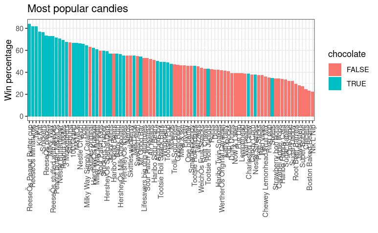

```r
ggplot(candy_df, aes(x = reorder(competitorname, -winpercent), y = winpercent, fill = chocolate)) +
  geom_bar(stat = "identity") +
  ggtitle("Most popular candies") +
  theme_bw() +
  theme(axis.text.x = element_text(angle = 90, vjust = 0.5, hjust=1)) +
  xlab("") +
  ylab("Win percentage")
```

This plot shows us that `Reeses Peanut Butter Cups` had the highest win percentage!

Additionally, we have color coded this plot to show whether or not a candy listed is chocolate or not. This appears to make it look like the chocolate candies have higher `winpercent` and thus are more popular than the non-chocolate candies.

But how can we ask this question in data science? We can use stats!

## Get the stats

We can ask if chocolate candies are more popular by using stats!

In the second part of this project our hypothesis is:

> Chocolate candies have a higher win percent than not chocolate candies

To start to ask this question, we can take averages and print these out here:

```r
# First we can just use averages to see what the differences are!
 candy_df %>%
  group_by(chocolate) %>%
  summarize(mean(winpercent))
```

| chocolate | mean(winpercent) |
| --- | --- |
| FALSE | 42.14226 |
| TRUE | 60.92153 |

60 sounds bigger than 42? But is that different enough to answer our question?

Another way to explore our hypothesis is use a formal statistical test (in this case, a t-test):

```r
chocolate <- filter(candy_df, chocolate) %>%
  pull(winpercent)

not_chocolate <- filter(candy_df, !chocolate) %>%
  pull(winpercent)

t.test(chocolate, not_chocolate,
         alternative = "greater")
```

```
    Welch Two Sample t-test

data:  chocolate and not_chocolate
t = 7.3031, df = 67.539, p-value = 2.082e-10
alternative hypothesis: true difference in means is greater than 0
95 percent confidence interval:
 14.49083      Inf
sample estimates:
mean of x mean of y
 60.92153  42.14226
```

This test tells us our p value (we’ll talk about those more later) is suppppppeer small so that yeah, 60 is different enough from 42 given the amount of data we gave this test.

### Conclusion

Write up your thoughts about this data science project here and answer the following questions:

- What did we find out about our questions? (what were our questions again?)

  In this project, we asked what the most popular Halloween candy is. After reviewing the resulting data, a second question arose: are chocolate candies more popular than their non-chocolate counterparts?
- How did we explore our questions?

  We explored our question by first plotting the ‘winpercent’ data, which tells us how many times survey participants chose a particular candy over other choices. Then, we used statistics to compare the average winrates of both groups, chocolate and non-chocolate, and perform a t-test to determine if the p-value was small enough to conclude a significant difference between the two averages.
- What did our explorations show us?

  Our explorations of the data showed us that ‘Reese’s Peanut Butter Cups’ is the most popular Halloween candy, based on the results of the survey, and that chocolate candies are more popular than non-chocolate candies.
- What follow up data science questions arise for you regarding this candy dataset now that we’ve explored it some?

  Do candies with a higher sugar content have a higher winrate percentage than candies that don’t have as much sugar? Does pricing have an effect on a candy’s popularity?

## Print out session info

Session info is a good thing to print out at the end of your notebooks so that you (and other folks) referencing your notebooks know what software versions and libraries you used to run the notebook.

[session information not shown]

```r
print("I finished my first Data Science project!")
```

```
[1] "I finished my first Data Science project!"
```